# Salary Trends in Data Science

TEAM 3 - Jeongmin An, Yeobi Hobson, Sameer Batra, Aditi Shukla

2025-03-24

# **Data Science Salary Trends (2020-2024)**

#### *Exploring how salaries have evolved and the key factors influencing earnings*

## **Table of Contents**

- Introduction
- Loading Dataset
- Data Cleaning
- Exploratory Data Analysis
- Statistical Analysis & Hypothesis Testing
- Conclusion
- References

## **1. Introduction**

Data science is a rapidly evolving field, and salaries vary widely based on experience, job role, work model, and company size.  
This analysis aims to uncover **salary trends from 2020 to 2024**, examining how different factors influence earnings.

Our key research questions:  
- How have salaries changed over time? - What is the relationship between experience and salary? - Do work models (remote vs. in-person) impact earnings? - How does company size influence salary distribution?

## **2. Loading Dataset**

**Source:** Kaggle Dataset (6,599 observations)  
**Years Covered:** 2020-2024

```r
#load packages
library(dplyr)
```

```r
library(ggplot2)

#load data
salaries = read.csv("data_science_salaries.csv")
```

## **3. Data cleaning**

### Check for missing values

```r
#check for missing values
total_na <- sum(is.na(salaries))
missing_summary <- colSums(is.na(salaries))
cat("Total missing values:", total_na, "\n")
```

```
## Total missing values: 0
```

```r
print(missing_summary)
```

```
##          job_title   experience_level    employment_type        work_models
##                  0                  0                  0                  0
##          work_year employee_residence             salary    salary_currency
##                  0                  0                  0                  0
##      salary_in_usd   company_location       company_size
##                  0                  0                  0
```

```r
# Display first few rows
head(salaries)
```

```
##        job_title experience_level employment_type work_models work_year
## 1  Data Engineer        Mid-level       Full-time      Remote      2024
## 2  Data Engineer        Mid-level       Full-time      Remote      2024
## 3 Data Scientist     Senior-level       Full-time      Remote      2024
## 4 Data Scientist     Senior-level       Full-time      Remote      2024
## 5   BI Developer        Mid-level       Full-time     On-site      2024
## 6   BI Developer        Mid-level       Full-time     On-site      2024
##   employee_residence salary salary_currency salary_in_usd company_location
## 1      United States 148100             USD        148100    United States
## 2      United States  98700             USD         98700    United States
## 3      United States 140032             USD        140032    United States
## 4      United States 100022             USD        100022    United States
## 5      United States 120000             USD        120000    United States
## 6      United States  62100             USD         62100    United States
##   company_size
## 1       Medium
## 2       Medium
## 3       Medium
## 4       Medium
## 5       Medium
## 6       Medium
```

Since no missing values are found, we proceed without handling missing data.

### Check data structure and summary

```r
str(salaries)
```

```
## 'data.frame':    6599 obs. of  11 variables:
##  $ job_title         : chr  "Data Engineer" "Data Engineer" "Data Scientist" "Data Scientist" ...
##  $ experience_level  : chr  "Mid-level" "Mid-level" "Senior-level" "Senior-level" ...
##  $ employment_type   : chr  "Full-time" "Full-time" "Full-time" "Full-time" ...
##  $ work_models       : chr  "Remote" "Remote" "Remote" "Remote" ...
##  $ work_year         : int  2024 2024 2024 2024 2024 2024 2024 2024 2024 2024 ...
##  $ employee_residence: chr  "United States" "United States" "United States" "United States" ...
##  $ salary            : int  148100 98700 140032 100022 120000 62100 250000 150000 219650 136000 ...
##  $ salary_currency   : chr  "USD" "USD" "USD" "USD" ...
##  $ salary_in_usd     : int  148100 98700 140032 100022 120000 62100 250000 150000 219650 136000 ...
##  $ company_location  : chr  "United States" "United States" "United States" "United States" ...
##  $ company_size      : chr  "Medium" "Medium" "Medium" "Medium" ...
```

```r
summary(salaries)
```

```
##   job_title         experience_level   employment_type    work_models
##  Length:6599        Length:6599        Length:6599        Length:6599
##  Class :character   Class :character   Class :character   Class :character
##  Mode  :character   Mode  :character   Mode  :character   Mode  :character
##
##
##
##    work_year    employee_residence     salary         salary_currency
##  Min.   :2020   Length:6599        Min.   :   14000   Length:6599
##  1st Qu.:2023   Class :character   1st Qu.:   96000   Class :character
##  Median :2023   Mode  :character   Median :  140000   Mode  :character
##  Mean   :2023                      Mean   :  179283
##  3rd Qu.:2023                      3rd Qu.:  187500
##  Max.   :2024                      Max.   :30400000
##  salary_in_usd    company_location   company_size
##  Min.   : 15000   Length:6599        Length:6599
##  1st Qu.: 95000   Class :character   Class :character
##  Median :138666   Mode  :character   Mode  :character
##  Mean   :145561
##  3rd Qu.:185000
##  Max.   :750000
```

### Check employee residence distribution

```r
# Create the grouped dataframe
country_counts <- as.data.frame(table(salaries$employee_residence))
colnames(country_counts) <- c("Country", "Frequency")

# Arrange by Frequency in ascending order
country_counts <- country_counts[order(country_counts$Frequency, decreasing = TRUE), ]

# View the result
country_counts
```

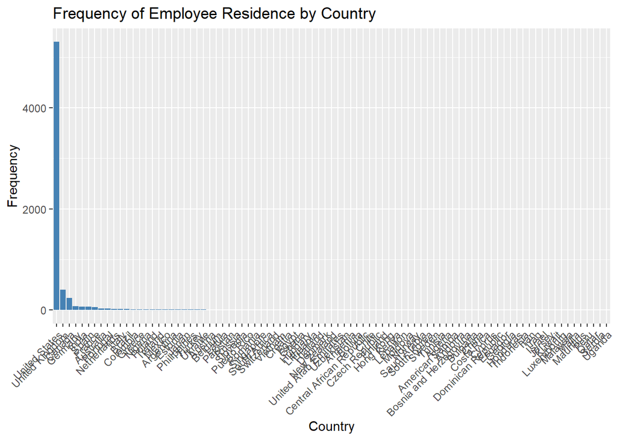

```r
# Create the barplot
ggplot(country_counts, aes(x = reorder(Country, -Frequency), y = Frequency)) +
  geom_bar(stat = "identity", fill = "steelblue") +
  labs(title = "Frequency of Employee Residence by Country",
       x = "Country",
       y = "Frequency") +
  theme(axis.text.x = element_text(angle = 45, hjust = 1))
```

### Filter for US-Based Employees & Remove unnecessary columns

```r
# Filter data(US)
us_residents_df <- subset(salaries, employee_residence == "United States")

##Since we are only working with us_residents dataframe we need to delete salary, salary_currency
us_residents_df <- subset(us_residents_df, select= -c(employee_residence, salary, salary_currency))

head(us_residents_df)
```

```
##        job_title experience_level employment_type work_models work_year
## 1  Data Engineer        Mid-level       Full-time      Remote      2024
## 2  Data Engineer        Mid-level       Full-time      Remote      2024
## 3 Data Scientist     Senior-level       Full-time      Remote      2024
## 4 Data Scientist     Senior-level       Full-time      Remote      2024
## 5   BI Developer        Mid-level       Full-time     On-site      2024
## 6   BI Developer        Mid-level       Full-time     On-site      2024
##   salary_in_usd company_location company_size
## 1        148100    United States       Medium
## 2         98700    United States       Medium
## 3        140032    United States       Medium
## 4        100022    United States       Medium
## 5        120000    United States       Medium
## 6         62100    United States       Medium
```

### Detecting Outliers Using IQR (Boxplot Method)

```r
# Function to find outliers using IQR and return entire rows
find_outliers <- function(data, column_name) {
  column <- data[[column_name]]
  Q1 <- quantile(column, 0.25, na.rm = TRUE)
  Q3 <- quantile(column, 0.75, na.rm = TRUE)
  IQR <- Q3 - Q1

  # Define lower and upper bounds
  lower_bound <- Q1 - 1.5 * IQR
  upper_bound <- Q3 + 1.5 * IQR

  # Identify outliers (rows where the value is outside the bounds)
  outliers <- data[column < lower_bound | column > upper_bound, ]
  return(outliers)
}

# Apply function to salary and salary_in_usd
outliers_salary_usd <- find_outliers(us_residents_df, "salary_in_usd")
outliers_salary_usd
```

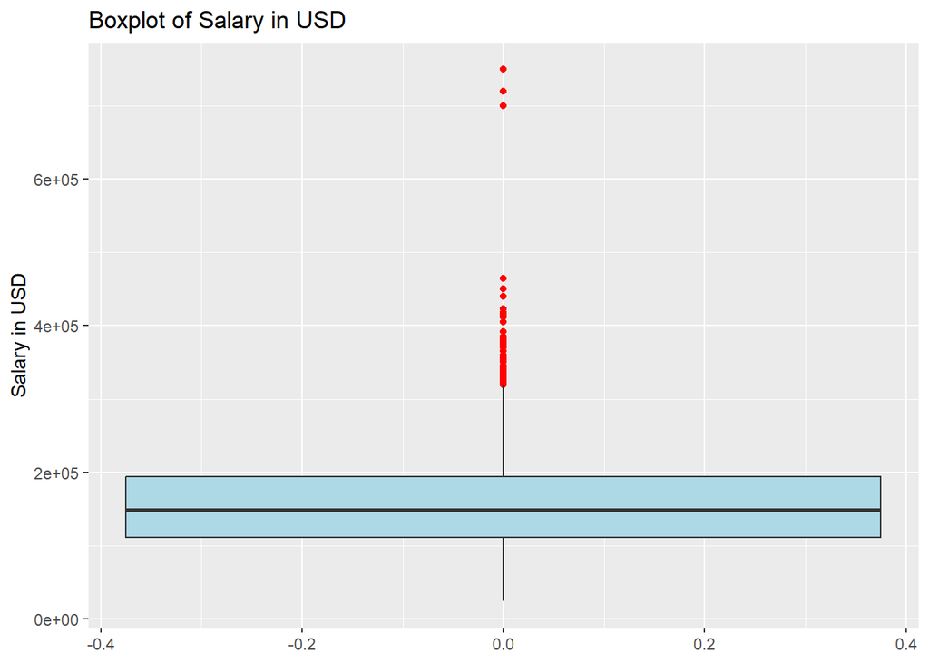

```r
# Boxplot for Salary in USD
ggplot(us_residents_df, aes(y = salary_in_usd)) +
  geom_boxplot(fill = "lightblue", outlier.color = "red") +
  labs(title = "Boxplot of Salary in USD", y = "Salary in USD")
```

### Remove outliers

```r
# Get the indices of the rows with outliers in salary and salary_in_usd
outlier_rows_salary_usd <- which(us_residents_df$salary_in_usd %in% outliers_salary_usd$salary_in_usd)

# Remove outliers from the original dataset using subset
cleaned_salaries <- us_residents_df[-outlier_rows_salary_usd, ]
cleaned_salaries
```

After removing the outliers, there are 5204 values in the dataframe. This means that 101 values were outliers.

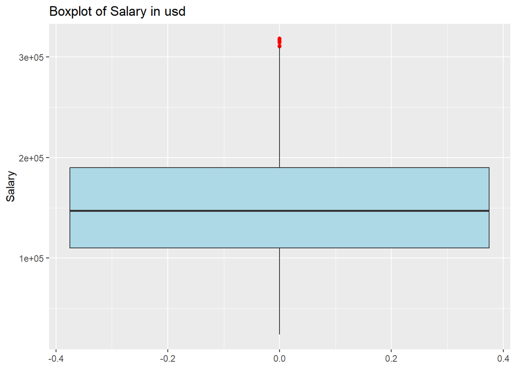

```r
ggplot(cleaned_salaries, aes(y = salary_in_usd)) +
  geom_boxplot(fill = "lightblue", outlier.color = "red") +
  labs(title = "Boxplot of Salary in usd", y = "Salary")
```

### Detecting Outliers Using the ezids package

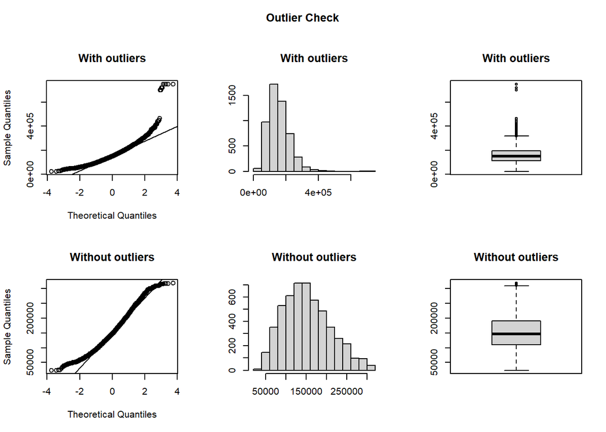

```
## Outliers identified: 101
## Proportion (%) of outliers: 1.9
## Mean of the outliers: 392733
## Mean without removing outliers: 157780.9
## Mean if we remove outliers: 153221
## Outliers successfully removed
```

```r
library(ezids)

# Outlier Removal + Visualization
us_residents_clean <- ezids::outlierKD2(us_residents_df, salary_in_usd, rm = TRUE, boxplt = TRUE, qqplt = TRUE)
```

[figure not shown]

```r
# Check normality after removing outliers
qqnorm(us_residents_clean$salary_in_usd, main = "QQ-Plot for Salary After Outlier Removal", col = "blue")
qqline(us_residents_clean$salary_in_usd, col = "red")
```

## **4. Exploratory Data Analysis**

### 1) How have salary trends in data science evolved from 2020 to 2024?

```r
#Check work_year value
unique(cleaned_salaries$work_year)
```

```
## [1] 2024 2023 2022 2021 2020
```

```r
# Compute average salary by year
salary_trends <- cleaned_salaries %>%
  group_by(work_year) %>%
  summarise(
    Avg_Salary_USD = mean(salary_in_usd, na.rm = TRUE),
    Count = n()
  )

print(salary_trends)
```

```
## # A tibble: 5 × 3
##   work_year Avg_Salary_USD Count
##       <int>          <dbl> <int>
## 1      2020        132342     25
## 2      2021        141220.    86
## 3      2022        147344.   822
## 4      2023        155624.  3784
## 5      2024        147658.   487
```

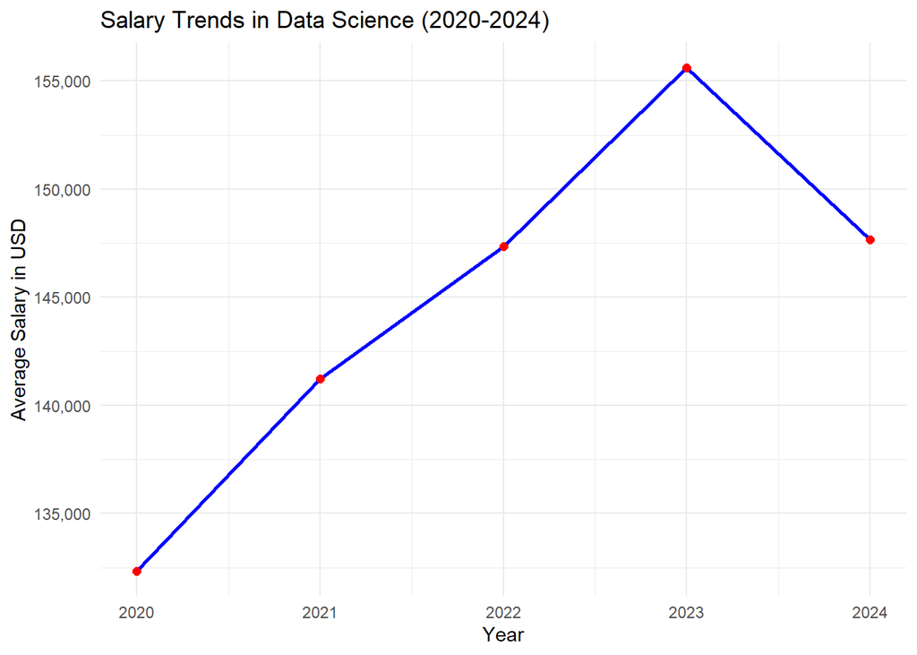

```r
# Line plot for Salary Trends
ggplot(salary_trends, aes(x = work_year, y = Avg_Salary_USD)) +
  geom_line(color = "blue", linewidth = 1) +
  geom_point(color = "red", size = 2) +
  scale_y_continuous(labels = scales::comma) +
  labs(title = "Salary Trends in Data Science (2020-2024)", x = "Year", y = "Average Salary in USD") +
  theme_minimal()
```

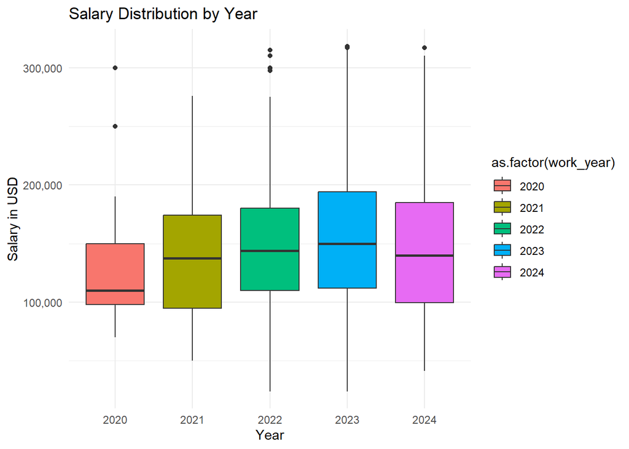

```r
# Box plot
ggplot(cleaned_salaries, aes(x = as.factor(work_year), y = salary_in_usd, fill = as.factor(work_year))) +
  geom_boxplot() +
  scale_y_continuous(labels = scales::comma) +
  labs(title = "Salary Distribution by Year",x = "Year",y = "Salary in USD") +
  theme_minimal()
```

```r
# ANOVA test
anova_result <- aov(salary_in_usd ~ as.factor(work_year), data = cleaned_salaries)
summary(anova_result)
```

```
##                        Df    Sum Sq   Mean Sq F value   Pr(>F)
## as.factor(work_year)    4 8.859e+10 2.215e+10   6.716 2.18e-05 ***
## Residuals            5199 1.715e+13 3.298e+09
## ---
## Signif. codes:  0 '***' 0.001 '**' 0.01 '*' 0.05 '.' 0.1 ' ' 1
```

The ANOVA test reveals a highly significant effect of work year on salary (F = 6.716, p = 2.18e-05), indicating that salaries in data science have significantly changed over time.

### 2) How do salaries vary across different experience levels in data science?

```r
#Check experience_level value
unique(cleaned_salaries$experience_level)
```

```
## [1] "Mid-level"       "Senior-level"    "Entry-level"     "Executive-level"
```

```r
# Compute average salary and salary in USD by experience level
experience_salary <- cleaned_salaries %>%
  group_by(experience_level) %>%
  summarise(
    Avg_Salary_USD = mean(salary_in_usd, na.rm = TRUE),
    Count = n()
  )

# Display summary table
print(experience_salary)
```

```
## # A tibble: 4 × 3
##   experience_level Avg_Salary_USD Count
##   <chr>                     <dbl> <int>
## 1 Entry-level             101236.   361
## 2 Executive-level         186557.   201
## 3 Mid-level               131124.  1153
## 4 Senior-level            163981.  3489
```

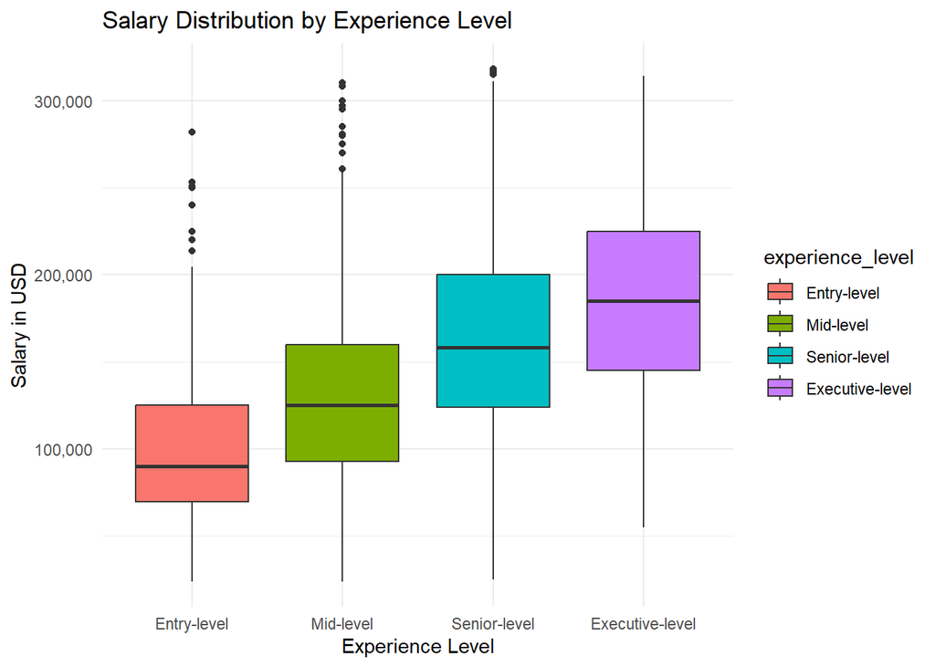

```r
library(scales)

cleaned_salaries$experience_level <- factor(
  cleaned_salaries$experience_level,
  levels = c("Entry-level", "Mid-level", "Senior-level", "Executive-level")
)

# Visualize with Boxplot
ggplot(cleaned_salaries, aes(x = experience_level, y = salary_in_usd, fill = experience_level)) +
  geom_boxplot() +
  labs(title = "Salary Distribution by Experience Level", x = "Experience Level", y = "Salary in USD") +
  scale_y_continuous(labels = scales::comma)+
  theme_minimal()
```

```r
library(dplyr)
filtered_data <- cleaned_salaries %>%
  filter(experience_level == "Entry-level" & salary_in_usd  )

# ANOVA test
anova_result <- aov(salary_in_usd ~ experience_level, data = cleaned_salaries)
summary(anova_result)
```

```
##                    Df    Sum Sq   Mean Sq F value Pr(>F)
## experience_level    3 2.166e+12 7.220e+11   249.2 <2e-16 ***
## Residuals        5200 1.507e+13 2.898e+09
## ---
## Signif. codes:  0 '***' 0.001 '**' 0.01 '*' 0.05 '.' 0.1 ' ' 1
```

The ANOVA test shows a highly significant effect of experience level on salary (F = 249.2, p < 2e-16), indicating substantial salary differences across experience levels.

### 3) What is the average salary difference between work models data science jobs?

```r
#Check work_models value
unique(cleaned_salaries$work_models)
```

```
## [1] "Remote"  "On-site" "Hybrid"
```

```r
# Compute average salary by work model
work_model_salary <- cleaned_salaries %>%
  group_by(work_models) %>%
  summarise(
    Avg_Salary_USD = mean(salary_in_usd, na.rm = TRUE),
    Count = n()
  )
print(work_model_salary)
```

```
## # A tibble: 3 × 3
##   work_models Avg_Salary_USD Count
##   <chr>                <dbl> <int>
## 1 Hybrid             128468.    40
## 2 On-site            154398.  3200
## 3 Remote             151807.  1964
```

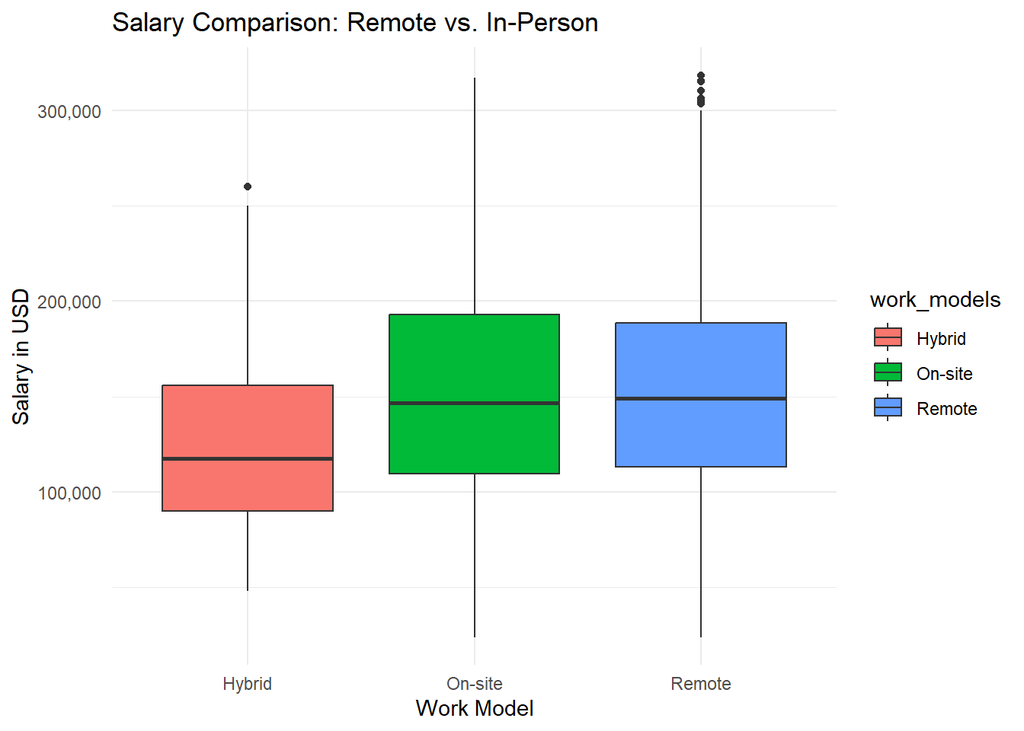

```r
# Boxplot of Salary by Work Model
ggplot(cleaned_salaries, aes(x = work_models, y = salary_in_usd, fill = work_models)) +
  geom_boxplot() +
  scale_y_continuous(labels = scales::comma) +
  labs(title = "Salary Comparison: Remote vs. In-Person", x = "Work Model", y = "Salary in USD")+
  theme_minimal()
```

```r
# ANOVA test
anova_result <- aov(salary_in_usd ~ work_models, data = cleaned_salaries)
summary(anova_result)
```

```
##               Df    Sum Sq   Mean Sq F value  Pr(>F)
## work_models    2 3.287e+10 1.643e+10   4.969 0.00698 **
## Residuals   5201 1.720e+13 3.307e+09
## ---
## Signif. codes:  0 '***' 0.001 '**' 0.01 '*' 0.05 '.' 0.1 ' ' 1
```

The ANOVA test identifies a statistically significant difference in salaries across work models (F = 4.969, p = 0.00698), suggesting that at least one work model has a significantly different average salary.”

### 4) Difference in salaries with respect to company size

```r
#Check company_size value
unique(cleaned_salaries$company_size)
```

```
## [1] "Medium" "Large"  "Small"
```

```r
salary_summary <- cleaned_salaries %>%
  group_by(company_size) %>%
  summarise(
    mean_salary = mean(salary_in_usd, na.rm = TRUE),
    median_salary = median(salary_in_usd, na.rm = TRUE),
    count = n()
  )

print(salary_summary)
```

```
## # A tibble: 3 × 4
##   company_size mean_salary median_salary count
##   <chr>              <dbl>         <dbl> <int>
## 1 Large            152726.        145000   311
## 2 Medium           153590.        147200  4843
## 3 Small            120570.        112500    50
```

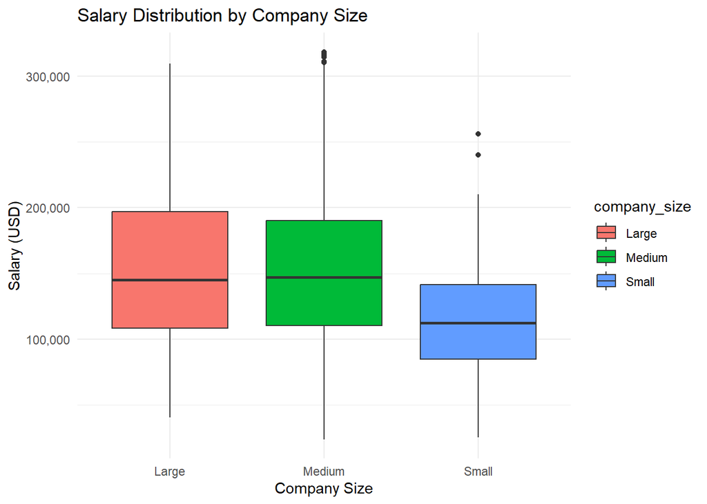

```r
#Box plot for Salary distribution by company size
ggplot(cleaned_salaries, aes(x = company_size, y = salary_in_usd, fill = company_size)) +
  geom_boxplot() +
  labs(title = "Salary Distribution by Company Size", x = "Company Size", y = "Salary (USD)") +
  scale_y_continuous(labels = comma)+
  theme_minimal()
```

```r
# ANOVA test
anova_result <- aov(salary_in_usd ~ company_size, data = cleaned_salaries)
summary(anova_result)
```

```
##                Df    Sum Sq   Mean Sq F value   Pr(>F)
## company_size    2 5.404e+10 2.702e+10    8.18 0.000284 ***
## Residuals    5201 1.718e+13 3.303e+09
## ---
## Signif. codes:  0 '***' 0.001 '**' 0.01 '*' 0.05 '.' 0.1 ' ' 1
```

The ANOVA test reveals a statistically significant effect of company size on salary (F = 8.18, p = 0.000284), indicating that salaries vary significantly across different company sizes.

### 5) Which job title earned the most in 2024?

```r
salaries_2024 <- cleaned_salaries %>%
  filter(work_year == 2024)

# average salaries by job title
top_job <- salaries_2024 %>%
  group_by(job_title) %>%
  summarise(
    mean_salary = mean(salary_in_usd, na.rm = TRUE),
    max_salary = max(salary_in_usd, na.rm = TRUE),
    count = n()
  ) %>%
  arrange(desc(mean_salary))
print(top_job)
```

```
## # A tibble: 35 × 4
##    job_title                      mean_salary max_salary count
##    <chr>                                <dbl>      <int> <int>
##  1 Managing Director Data Science     260000      260000     1
##  2 AI Architect                       229662.     317000     4
##  3 Data Product Manager               213150      227200     2
##  4 Computer Vision Engineer           210000      235000     2
##  5 Director of Data Science           202500      225000     2
##  6 Applied Scientist                  195279.     260000     7
##  7 Data Science Engineer              190000      245000     2
##  8 Machine Learning Engineer          187610.     303400    55
##  9 Machine Learning Scientist         186500      252000     3
## 10 Research Engineer                  179242.     295000    17
## # ℹ 25 more rows
```

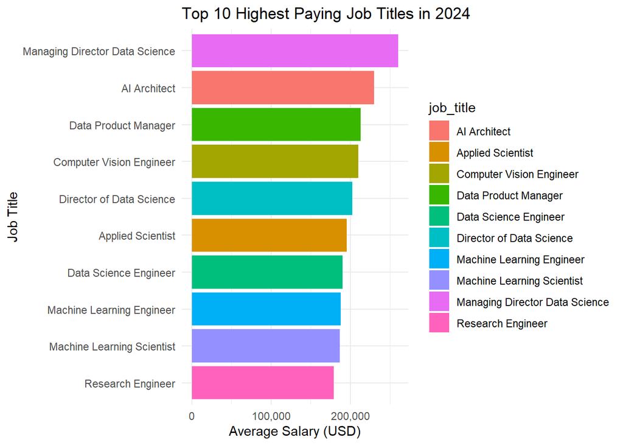

```r
#top 10
top_10_jobs <- top_job %>% slice_head(n = 10)

ggplot(top_10_jobs, aes(x = reorder(job_title, mean_salary), y = mean_salary, fill = job_title)) +
  geom_bar(stat = "identity") +
  coord_flip() +
  labs(title = "Top 10 Highest Paying Job Titles in 2024", x = "Job Title", y = "Average Salary (USD)") +
  scale_y_continuous(labels = scales::comma) +
  theme_minimal()
```

```r
highest_paid_job <- salaries_2024 %>%
  slice_max(salary_in_usd, n = 1)
print(highest_paid_job)
```

```
##      job_title experience_level employment_type work_models work_year
## 1 AI Architect     Senior-level       Full-time     On-site      2024
##   salary_in_usd company_location company_size
## 1        317000    United States       Medium
```

### 5-1) What are the most common job title (Which job title hire the most)?

#### Filter data by job title

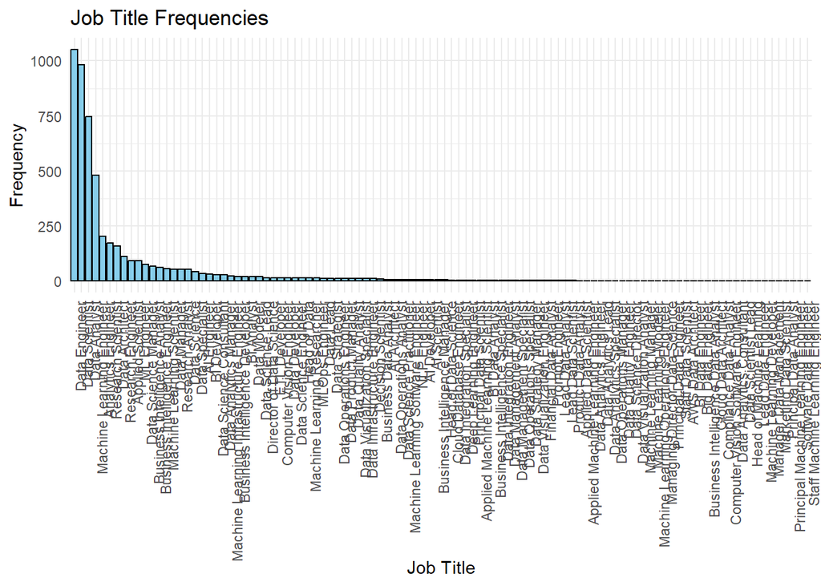

```r
# Step 1: Calculate the frequencies of each job title
job_title_freq <- table(cleaned_salaries$job_title)

# Step 2: Create the frequency table as a data frame for plotting
job_title_freq_df <- as.data.frame(job_title_freq)
colnames(job_title_freq_df) <- c("job_title", "frequency")

# Plotting the histogram
library(ggplot2)

ggplot(job_title_freq_df, aes(x = reorder(job_title, -frequency), y = frequency)) +
  geom_bar(stat = "identity", fill = "skyblue", color = "black") +  # Bar plot for categorical data
  labs(
    title = "Job Title Frequencies",  # Plot title
    x = "Job Title",  # X-axis label
    y = "Frequency"   # Y-axis label
  ) +
  theme_minimal() +  # Minimal theme
  theme(axis.text.x = element_text(angle = 90, hjust = 1))  # Rotate x-axis labels for readability
```

```r
freq_table <- table(cleaned_salaries$job_title)

freq_df <- as.data.frame(freq_table, stringsAsFactors = FALSE)

colnames(freq_df) <- c("job_title", "frequency")

threshold <- 20

freq_df$job_title[freq_df$frequency <= threshold] <- "Other"

freq_df <- aggregate(frequency ~ job_title, data = freq_df, sum)

freq_df <- freq_df[order(-freq_df$frequency), ]

cleaned_salaries$job_title <- ifelse(
  cleaned_salaries$job_title %in% freq_df$job_title,
  cleaned_salaries$job_title,
  "Other"
)
#cleaned_salaries
```

Rather than keeping job titles that appeared less than 20 times as separate titles, we aggregated them into “other” keyword.

```r
freq_df
```

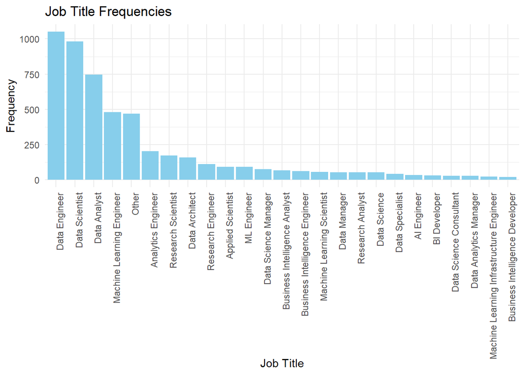

```r
ggplot(freq_df, aes(x = reorder(job_title, -frequency), y = frequency)) +
  geom_bar(stat = "identity", fill = "skyblue") +  # Bar plot
  labs(
    title = "Job Title Frequencies",  # Plot title
    x = "Job Title",  # X-axis label
    y = "Frequency"   # Y-axis label
  ) +
  theme_minimal()+
  theme(axis.text.x = element_text(angle = 90, hjust = 1))  # Rotate x-axis labels
```

The above graph shows that job titles are right skewed.

```r
freq_df
```

```r
cleaned_salaries
unique(cleaned_salaries$employment_type)
```

```r
str(cleaned_salaries)
```

```
## 'data.frame':    5204 obs. of  8 variables:
##  $ job_title       : chr  "Data Engineer" "Data Engineer" "Data Scientist" "Data Scientist" ...
##  $ experience_level: Factor w/ 4 levels "Entry-level",..: 2 2 3 3 2 2 1 1 4 4 ...
##  $ employment_type : chr  "Full-time" "Full-time" "Full-time" "Full-time" ...
##  $ work_models     : chr  "Remote" "Remote" "Remote" "Remote" ...
##  $ work_year       : int  2024 2024 2024 2024 2024 2024 2024 2024 2024 2024 ...
##  $ salary_in_usd   : int  148100 98700 140032 100022 120000 62100 250000 150000 219650 136000 ...
##  $ company_location: chr  "United States" "United States" "United States" "United States" ...
##  $ company_size    : chr  "Medium" "Medium" "Medium" "Medium" ...
```

## **5. Statistical Analysis & Hypothesis Testing**

### Shapiro-Wilk test

```r
set.seed(123)
# Subset the data into Full-time and Part-time groups
full_time_data <- cleaned_salaries[cleaned_salaries$employment_type == "Full-time", ]
# using only 5000 because shapiro only accepts sample size between 3 to 5000
full_time_sample <- full_time_data[sample(nrow(full_time_data), 5000), ]
part_time_data <- cleaned_salaries[cleaned_salaries$employment_type == "Part-time", ]
contract_data <- cleaned_salaries[cleaned_salaries$employment_type=="Contract", ]

# Conduct the Shapiro-Wilk test for Full-time salaries
shapiro_test_full_time <- shapiro.test(full_time_sample$salary_in_usd)
print(shapiro_test_full_time)
```

```
##
##  Shapiro-Wilk normality test
##
## data:  full_time_sample$salary_in_usd
## W = 0.98061, p-value < 2.2e-16
```

```r
# Conduct the Shapiro-Wilk test for Part-time salaries
shapiro_test_part_time <- shapiro.test(part_time_data$salary_in_usd)
print(shapiro_test_part_time)
```

```
##
##  Shapiro-Wilk normality test
##
## data:  part_time_data$salary_in_usd
## W = 0.91907, p-value = 0.4491
```

```r
shapiro.test(contract_data$salary_in_usd)
```

```
##
##  Shapiro-Wilk normality test
##
## data:  contract_data$salary_in_usd
## W = 0.86805, p-value = 0.1172
```

Null Hypothesis: The salary data for Full-time employees is normally distributed. Alternate Hypothesis: The salary data for Full-time employees is not normally distributed. Results: Since the p-value is less than 2.2e-16, which is far smaller than the significance level (α = 0.05), we reject the null hypothesis. This suggests that there is enough evidence to conclude that the salary data for Full-time employees is not normally distributed.

Null Hypothesis: The salary data for Part-time employees is normally distributed. Alternate Hypothesis: Part-time salary data does not significantly deviate from normality, meaning it is more likely to be normally distributed. Results: Since the p-value is 0.4491, which is greater than the significance level (α = 0.05), we fail to reject the null hypothesis. This suggests that there is insufficient evidence to conclude that the salary data for Part-time employees is not normally distributed.

Null Hypothesis: The salary data for Contract employees is normally distributed. Alternate Hypothesis: The salary data for Contract employees is not normally distributed. Results: Since the p-value is 0.1172, which is greater than the significance level (α = 0.05), we fail to reject the null hypothesis. This suggests that there is insufficient evidence to conclude that the salary data for Contract employees is not normally distributed.

```r
data_manager <- cleaned_salaries[cleaned_salaries$job_title == "Data Manager", ]
shapiro.test(data_manager$salary_in_usd)
```

```
##
##  Shapiro-Wilk normality test
##
## data:  data_manager$salary_in_usd
## W = 0.97033, p-value = 0.1905
```

```r
research_analyst <- cleaned_salaries[cleaned_salaries$job_title == "Research Analyst", ]
shapiro.test(research_analyst$salary_in_usd)
```

```
##
##  Shapiro-Wilk normality test
##
## data:  research_analyst$salary_in_usd
## W = 0.90298, p-value = 0.0003165
```

```r
data_engineer <- cleaned_salaries[cleaned_salaries$job_title == "Data Engineer", ]
shapiro.test(data_engineer$salary_in_usd)
```

```
##
##  Shapiro-Wilk normality test
##
## data:  data_engineer$salary_in_usd
## W = 0.97815, p-value = 1.745e-11
```

```r
data_scientist <- cleaned_salaries[cleaned_salaries$job_title == "Data Scientist", ]
shapiro.test(data_scientist$salary_in_usd)
```

```
##
##  Shapiro-Wilk normality test
##
## data:  data_scientist$salary_in_usd
## W = 0.98507, p-value = 1.818e-08
```

```r
data_analyst <- cleaned_salaries[cleaned_salaries$job_title == "Data Analyst", ]
shapiro.test(data_analyst$salary_in_usd)
```

```
##
##  Shapiro-Wilk normality test
##
## data:  data_analyst$salary_in_usd
## W = 0.96718, p-value = 6.878e-12
```

```r
analytics_engineer <- cleaned_salaries[cleaned_salaries$job_title == "Analytics Engineer", ]
shapiro.test(analytics_engineer$salary_in_usd)
```

```
##
##  Shapiro-Wilk normality test
##
## data:  analytics_engineer$salary_in_usd
## W = 0.98744, p-value = 0.07004
```

Null Hypothesis: The salary data for Data Manager is normally distributed. Alternate hypothesis: The salary data for Data Manager is not normally distributed. results: Since the p-value (0.1905) is greater than the significance level (α = 0.05), we fail to reject the null hypothesis. This suggests that there is not enough evidence to conclude that the salary data for Data Manager is not normally distributed. Therefore, we can assume that the data follows a normal distribution.

Null Hypothesis: The salary data for research analyst is normally distributed. Alternate hypothesis: The salary data for research analyst is not normally distributed. results: Since the p-value (0.0003165) is much less than the significance level (α = 0.05), we reject the null hypothesis. This indicates that there is enough evidence to conclude that the salary data for Research Analysts is not normally distributed.

Final Result: From the above results we can conclude that only “Data Manager” and “Analytics Engineer” have normal distribution

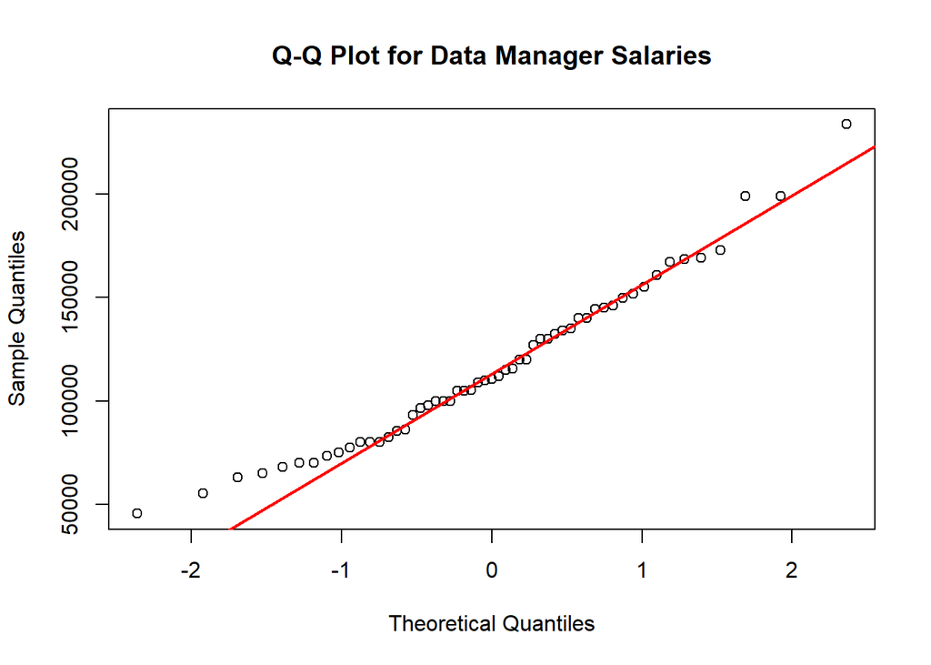

```r
qqnorm(data_manager$salary_in_usd, main = "Q-Q Plot for Data Manager Salaries")
qqline(data_manager$salary_in_usd, col = "red", lwd = 2)
```

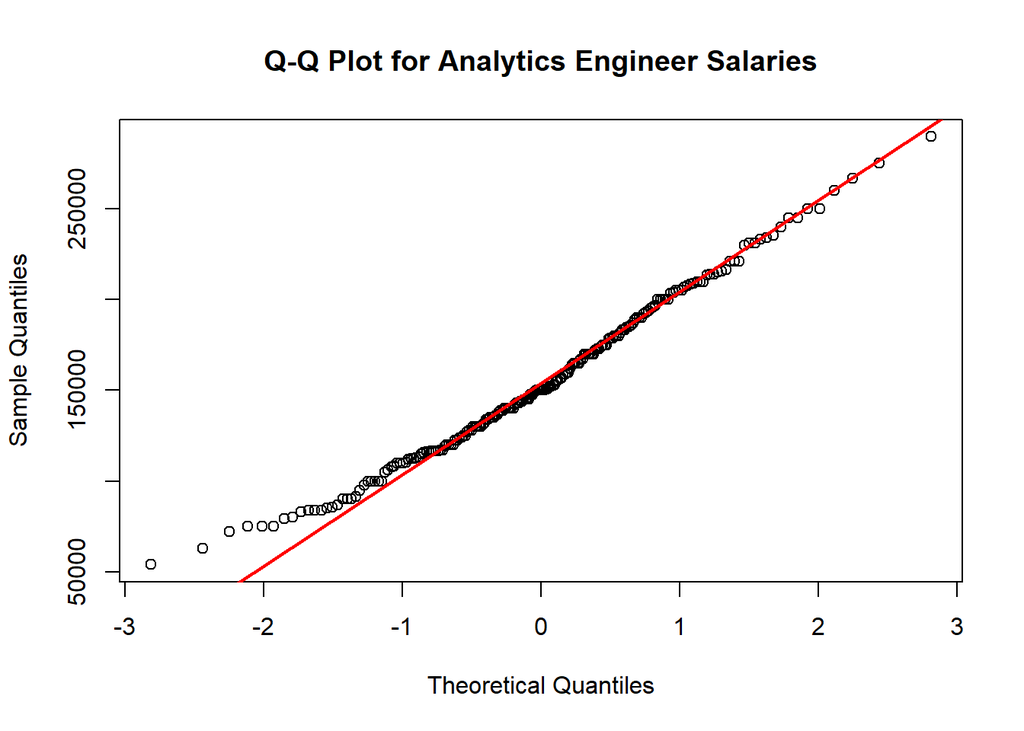

```r
qqnorm(analytics_engineer$salary_in_usd, main = "Q-Q Plot for Analytics Engineer Salaries")
qqline(analytics_engineer$salary_in_usd, col = "red", lwd = 2)
```

### T-test

```r
t_test_result <- t.test(data_manager$salary_in_usd, analytics_engineer$salary_in_usd)

# Print the t-test result
print(t_test_result)
```

```
##
##  Welch Two Sample t-test
##
## data:  data_manager$salary_in_usd and analytics_engineer$salary_in_usd
## t = -6.1742, df = 97.927, p-value = 1.513e-08
## alternative hypothesis: true difference in means is not equal to 0
## 95 percent confidence interval:
##  -51096.20 -26239.23
## sample estimates:
## mean of x mean of y
##  116371.2  155038.9
```

Null Hypothesis: The average salaries of Data Managers and Analytics Engineers are equal. Alternative Hypothesis: The average salaries of Data Managers and Analytics Engineers are not equal. Results: Given that the p-value is 1.513e-08 (which is much smaller than 0.05), we reject the null hypothesis. This means that there is a statistically significant difference in the average salaries of Data Managers and Analytics Engineers, with Analytics Engineers earning more on average than Data Managers.

```r
#Conduct shapiro test and t-test if applicable on work models column
unique(cleaned_salaries$work_models)
```

```
## [1] "Remote"  "On-site" "Hybrid"
```

```r
remote <- cleaned_salaries[cleaned_salaries$work_models == "Remote", ]
shapiro.test(remote$salary_in_usd)
```

```
##
##  Shapiro-Wilk normality test
##
## data:  remote$salary_in_usd
## W = 0.98781, p-value = 7.492e-12
```

```r
on_site_salaries <- cleaned_salaries[cleaned_salaries$work_models == "On-site", ]
shapiro.test(on_site_salaries$salary_in_usd)
```

```
##
##  Shapiro-Wilk normality test
##
## data:  on_site_salaries$salary_in_usd
## W = 0.97608, p-value < 2.2e-16
```

```r
hybrid <- cleaned_salaries[cleaned_salaries$work_models == "Hybrid", ]
shapiro.test(hybrid$salary_in_usd)
```

```
##
##  Shapiro-Wilk normality test
##
## data:  hybrid$salary_in_usd
## W = 0.94075, p-value = 0.03666
```

Null Hypothesis: All of the work models are normally distributed Alternate Hypothesis: None of the work models are normally distributed Results: Since all of the p-values(7.492e-12, 2.2e-16, 0.03666) are less than 0.05 we reject the null hypothesis. None of the work models (Remote, On-site, or Hybrid) have salaries that follow a normal distribution based on the Shapiro-Wilk test results.

```r
cleaned_salaries
```

### Chi-Squared Test

#### conducting chi-squared test between employment_type and work_models

```r
table_data <- table(cleaned_salaries$employment_type, cleaned_salaries$work_models)
chisq_test <- chisq.test(table_data)
cat("\n\n")
```

```r
cat("Chi-Squared Test for Employment Type and Work Models")
```

```
## Chi-Squared Test for Employment Type and Work Models
```

```r
print(chisq_test)
```

```
##
##  Pearson's Chi-squared test
##
## data:  table_data
## X-squared = 24.389, df = 4, p-value = 6.673e-05
```

```r
chisq_test$expected
```

```
##
##                  Hybrid     On-site      Remote
##   Contract   0.06917756    5.534204    3.396618
##   Full-time 39.90776326 3192.621061 1959.471176
##   Part-time  0.02305919    1.844735    1.132206
```

Null Hypothesis: There is no association between employment type and work model (they are independent). Alternate Hypothesis: There is an association between employment type and work model (they are dependent). Results: Since the p-value(6.673e-05) is less than 0.05, we reject the null hypothesis. There is a statistically significant association between employment type and work model. *However, we should be cautious about these results because, for a chi-squared test, the expected frequencies should be greater than 5. In this case, the expected counts for Hybrid: Contract, Contract:Remote, Part-time: Hybrid, Part-time: On-site, and Part-time: Remote are all less than 5, which may affect the reliability of the test.*

#### conducting chi-squared test between company_size and work_models

```r
table_data <- table(cleaned_salaries$company_size, cleaned_salaries$work_models)
chisq_test <- chisq.test(table_data)
cat("\n\n")
```

```r
cat("Chi-Squared Test for Company Size and Work Models")
```

```
## Chi-Squared Test for Company Size and Work Models
```

```r
print(chisq_test)
```

```
##
##  Pearson's Chi-squared test
##
## data:  table_data
## X-squared = 421.91, df = 4, p-value < 2.2e-16
```

```r
chisq_test$expected
```

```
##
##              Hybrid    On-site    Remote
##   Large   2.3904689  191.23751  117.3720
##   Medium 37.2252114 2978.01691 1827.7579
##   Small   0.3843198   30.74558   18.8701
```

Null Hypothesis: There is no association between company_size and work model (they are independent). Alternate Hypothesis: There is an association between company_size and work model (they are dependent). Results: Since the p-value(<2.2e-16) is less than 0.05, we reject the null hypothesis. There is a statistically significant association between company_size and work model. *However, we should be cautious about these results because, for a chi-squared test, the expected frequencies should be greater than 5. In this case, the expected counts for Hybrid: Large, small:hybrid are all less than 5, which may affect the reliability of the test.*

#### conducting chi-squared test between experience level and work_models

```r
table_data <- table(cleaned_salaries$work_models, cleaned_salaries$experience_level)
chisq_test <- chisq.test(table_data)
cat("\n\n")
```

```r
cat("Chi-Squared Test for Experience Level and Work Models")
```

```
## Chi-Squared Test for Experience Level and Work Models
```

```r
print(chisq_test)
```

```
##
##  Pearson's Chi-squared test
##
## data:  table_data
## X-squared = 104.43, df = 6, p-value < 2.2e-16
```

```r
chisq_test$expected
```

```
##
##           Entry-level  Mid-level Senior-level Executive-level
##   Hybrid     2.774789   8.862414     26.81783        1.544965
##   On-site  221.983090 708.993082   2145.42659      123.597233
##   Remote   136.242121 435.144504   1316.75557       75.857802
```

Null Hypothesis: There is no association between work model and experience level (they are independent). Alternate Hypothesis: There is an association between work model and experience level (they are dependent). Results: Since the p-value(<2.2e-16) is less than 0.05, we reject the null hypothesis. There is a statistically significant association between work model and experience level. *However, we should be cautious about these results because, for a chi-squared test, the expected frequencies should be greater than 5. In this case, the expected counts for Hybrid: Entry-level, and Hybrid:Executive-level are all less than 5, which may affect the reliability of the test.*

#### conducting chi-squared test between experience level and employement type

```r
table_data <- table(cleaned_salaries$experience_level, cleaned_salaries$employment_type)
chisq_test <- chisq.test(table_data)
cat("\n\n")
```

```r
cat("Chi-Squared Test for Experience Level and Employment Type")
```

```
## Chi-Squared Test for Experience Level and Employment Type
```

```r
print(chisq_test)
```

```
##
##  Pearson's Chi-squared test
##
## data:  table_data
## X-squared = 50.918, df = 6, p-value = 3.076e-09
```

```r
chisq_test$expected
```

```
##
##                    Contract Full-time Part-time
##   Entry-level     0.6243274  360.1676 0.2081091
##   Mid-level       1.9940430 1150.3413 0.6646810
##   Senior-level    6.0340123 3480.9547 2.0113374
##   Executive-level 0.3476172  200.5365 0.1158724
```

Null Hypothesis: There is no association between experience level and employment type(they are independent). Alternate Hypothesis: There is an association between experience level and employment type(they are dependent). Results: Since the p-value(3.076e-09) is less than 0.05, we reject the null hypothesis. There is a statistically significant association between experience level and employment type. *However, we should be cautious about these results because, for a chi-squared test, the expected frequencies should be greater than 5. In this case, the expected counts for Entry-level:contract, Executive-level:contract, Entry-level:Part-time, Executive-level and part-time, mid-level:contract, mid-level:part-time and senior-level:part-time are all less than 5, which may affect the reliability of the test.*

## **References**

1. Kaggle: Data Science Salaries Dataset
2. Tidyverse Package Documentation
3. R Graphics Cookbook